# Practical machine learning Assignment

Anudeep M

March 26, 2017

## Introduction:

The training data for this project are available here: https://d396qusza40orc.cloudfront.net/predmachlearn/pml-training.csv

The test data are available here: https://d396qusza40orc.cloudfront.net/predmachlearn/pml-testing.csv

In this project, the goal is to use data from accelerometers on the belt, forearm, arm, and dumbell of 6 participants,who were asked to perform barbell lifts correctly and incorrectly in 5 different ways. The goal of your project is to predict the manner in which they did the exercise. This is the “classe” variable in the training set.

```r
library(caret)
df=read.csv('pml-training.csv')
dim(df)
```

```
## [1] 19622   160
```

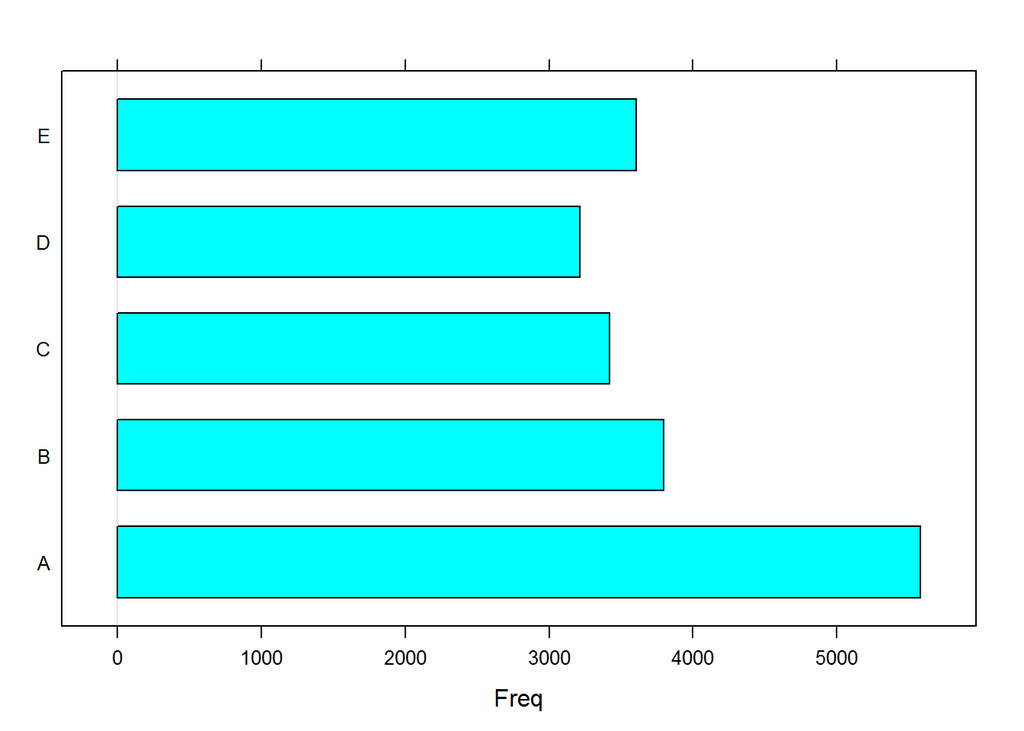

```r
barchart(df$classe)
```

The training data consists of 19622 observations and 160 variables. This is high dimensional data to implement a “random Forest” classification on the data. The variables that are not useful for analysis are removed and the all the measurement variables are converted to numeric data type to make sure data types of the measurements are correct.

```r
df[,c(1,2,3,4,5,6,7)]=NULL
for(i in seq(1,152)){

    df[,i]=as.numeric(df[,i])
}
```

The test data has been loaded and the same data manipulation as performed on the training data is performed on the test dataset.

```r
test=read.csv("pml-testing.csv")
dim(test)
```

```
## [1]  20 160
```

```r
test[,c(1,2,3,4,5,6,7)]=NULL
for(i in seq(1,152)){

    test[,i]=as.numeric(test[,i])
}
```

```r
x=colSums(is.na(df))
y=colSums(is.na(test))
newdf=df[,(x==0 & y==0)]
newtest=test[,(x==0 & y==0)]
dim(newdf)
```

```
## [1] 19622    53
```

```r
dim(newtest)
```

```
## [1] 20 53
```

Finally, the dimensionality has been reduced to 53 variables from initial 160 varibales of which the “classe” is the variables to be predicted. The variables used are:

```r
names(newdf)
```

```
##  [1] "roll_belt"            "pitch_belt"           "yaw_belt"
##  [4] "total_accel_belt"     "gyros_belt_x"         "gyros_belt_y"
##  [7] "gyros_belt_z"         "accel_belt_x"         "accel_belt_y"
## [10] "accel_belt_z"         "magnet_belt_x"        "magnet_belt_y"
## [13] "magnet_belt_z"        "roll_arm"             "pitch_arm"
## [16] "yaw_arm"              "total_accel_arm"      "gyros_arm_x"
## [19] "gyros_arm_y"          "gyros_arm_z"          "accel_arm_x"
## [22] "accel_arm_y"          "accel_arm_z"          "magnet_arm_x"
## [25] "magnet_arm_y"         "magnet_arm_z"         "roll_dumbbell"
## [28] "pitch_dumbbell"       "yaw_dumbbell"         "total_accel_dumbbell"
## [31] "gyros_dumbbell_x"     "gyros_dumbbell_y"     "gyros_dumbbell_z"
## [34] "accel_dumbbell_x"     "accel_dumbbell_y"     "accel_dumbbell_z"
## [37] "magnet_dumbbell_x"    "magnet_dumbbell_y"    "magnet_dumbbell_z"
## [40] "roll_forearm"         "pitch_forearm"        "yaw_forearm"
## [43] "total_accel_forearm"  "gyros_forearm_x"      "gyros_forearm_y"
## [46] "gyros_forearm_z"      "accel_forearm_x"      "accel_forearm_y"
## [49] "accel_forearm_z"      "magnet_forearm_x"     "magnet_forearm_y"
## [52] "magnet_forearm_z"     "classe"
```

Since this is a very large data set to perform a “random Forest” classication algorithm with a 10-fold cross-validation, the power of parallel Programming is leveraged upon.

```r
library(parallel)
library(doParallel)
cluster=makeCluster(detectCores()-1) ## leaving one for OS
registerDoParallel(cluster)

## Cross-validation with 10 folds
fitcontrol=trainControl(method="cv",number=10,allowParallel = TRUE)
## training "randomForest" model
##model=train(classe~.,data=df,method="rf",trControl=fitcontrol,na.action = na.roughfix)
model=train(classe~.,data=newdf,method="rf",trControl=fitcontrol)
## Stopping the cluster
stopCluster(cluster)
registerDoSEQ()
```

```r
predtrain=predict(model,newdata=newdf)
confusionMatrix(predtrain,newdf$classe)
```

```
## Confusion Matrix and Statistics
##
##           Reference
## Prediction    A    B    C    D    E
##          A 5580    0    0    0    0
##          B    0 3797    0    0    0
##          C    0    0 3422    0    0
##          D    0    0    0 3216    0
##          E    0    0    0    0 3607
##
## Overall Statistics
##
##                Accuracy : 1
##                  95% CI : (0.9998, 1)
##     No Information Rate : 0.2844
##     P-Value [Acc > NIR] : < 2.2e-16
##
##                   Kappa : 1
##  Mcnemar's Test P-Value : NA
##
## Statistics by Class:
##
##                      Class: A Class: B Class: C Class: D Class: E
## Sensitivity            1.0000   1.0000   1.0000   1.0000   1.0000
## Specificity            1.0000   1.0000   1.0000   1.0000   1.0000
## Pos Pred Value         1.0000   1.0000   1.0000   1.0000   1.0000
## Neg Pred Value         1.0000   1.0000   1.0000   1.0000   1.0000
## Prevalence             0.2844   0.1935   0.1744   0.1639   0.1838
## Detection Rate         0.2844   0.1935   0.1744   0.1639   0.1838
## Detection Prevalence   0.2844   0.1935   0.1744   0.1639   0.1838
## Balanced Accuracy      1.0000   1.0000   1.0000   1.0000   1.0000
```

```r
pred=predict(model,newdata=test)
pred
```

```
##  [1] B A B A A E D B A A B C B A E E A B B B
## Levels: A B C D E
```